# Training a Model to Predict Response

###### Author: Rajesh Acharya

```python
import pandas as pd
import numpy as np
dataset = 'DScasestudy.txt'
data = pd.read_csv(dataset,sep='\t')
print(data.head())
data.info()
data.describe()
```

```
   response  V1  V2  V3  V4  V5  V6  V7  V8  V9   ...    V16553  V16554  \
0         1   0   0   0   0   0   1   0   0   0   ...         1       0
1         1   0   0   0   0   0   1   0   0   0   ...         0       0
2         1   0   0   0   0   0   1   0   0   0   ...         0       0
3         1   0   0   0   0   0   1   0   0   0   ...         0       0
4         1   0   0   0   0   0   1   0   0   0   ...         0       0

   V16555  V16556  V16557  V16558  V16559  V16560  V16561  V16562
0       0       0       0       0       0       0       0       0
1       0       0       0       0       0       0       0       1
2       0       0       0       0       0       0       0       1
3       0       0       0       0       0       0       0       0
4       0       0       0       0       0       0       0       0

[5 rows x 16563 columns]
<class 'pandas.core.frame.DataFrame'>
RangeIndex: 530 entries, 0 to 529
Columns: 16563 entries, response to V16562
dtypes: int64(16563)
memory usage: 67.0 MB
```

|  | response | V1 | V2 | V3 | V4 | V5 | V6 | V7 | V8 | V9 | ... | V16553 | V16554 | V16555 | V16556 | V16557 | V16558 | V16559 | V16560 | V16561 | V16562 |
| --- | --- | --- | --- | --- | --- | --- | --- | --- | --- | --- | --- | --- | --- | --- | --- | --- | --- | --- | --- | --- | --- |
| count | 530.000000 | 530.000000 | 530.000000 | 530.000000 | 530.0 | 530.000000 | 530.0 | 530.000000 | 530.000000 | 530.0 | ... | 530.000000 | 530.0 | 530.0 | 530.000000 | 530.000000 | 530.000000 | 530.0 | 530.000000 | 530.0 | 530.000000 |
| mean | 0.232075 | 0.009434 | 0.009434 | 0.001887 | 0.0 | 0.020755 | 1.0 | 0.001887 | 0.030189 | 0.0 | ... | 0.158491 | 0.0 | 0.0 | 0.001887 | 0.020755 | 0.013208 | 0.0 | 0.003774 | 0.0 | 0.447170 |
| std | 0.422556 | 0.096761 | 0.096761 | 0.043437 | 0.0 | 0.142697 | 0.0 | 0.043437 | 0.171268 | 0.0 | ... | 0.365545 | 0.0 | 0.0 | 0.043437 | 0.142697 | 0.114270 | 0.0 | 0.061371 | 0.0 | 0.497671 |
| min | 0.000000 | 0.000000 | 0.000000 | 0.000000 | 0.0 | 0.000000 | 1.0 | 0.000000 | 0.000000 | 0.0 | ... | 0.000000 | 0.0 | 0.0 | 0.000000 | 0.000000 | 0.000000 | 0.0 | 0.000000 | 0.0 | 0.000000 |
| 25% | 0.000000 | 0.000000 | 0.000000 | 0.000000 | 0.0 | 0.000000 | 1.0 | 0.000000 | 0.000000 | 0.0 | ... | 0.000000 | 0.0 | 0.0 | 0.000000 | 0.000000 | 0.000000 | 0.0 | 0.000000 | 0.0 | 0.000000 |
| 50% | 0.000000 | 0.000000 | 0.000000 | 0.000000 | 0.0 | 0.000000 | 1.0 | 0.000000 | 0.000000 | 0.0 | ... | 0.000000 | 0.0 | 0.0 | 0.000000 | 0.000000 | 0.000000 | 0.0 | 0.000000 | 0.0 | 0.000000 |
| 75% | 0.000000 | 0.000000 | 0.000000 | 0.000000 | 0.0 | 0.000000 | 1.0 | 0.000000 | 0.000000 | 0.0 | ... | 0.000000 | 0.0 | 0.0 | 0.000000 | 0.000000 | 0.000000 | 0.0 | 0.000000 | 0.0 | 1.000000 |
| max | 1.000000 | 1.000000 | 1.000000 | 1.000000 | 0.0 | 1.000000 | 1.0 | 1.000000 | 1.000000 | 0.0 | ... | 1.000000 | 0.0 | 0.0 | 1.000000 | 1.000000 | 1.000000 | 0.0 | 1.000000 | 0.0 | 1.000000 |

8 rows × 16563 columns

The data presents 530 observations, a single target labeled response and 16562 features to test on. On first glance every feature looks binary. Some features such as v4, v6 and v9 also seem to contain a single response for every observation, which will not be helpful in prediction and should be removed.

```python
#Check for NAs
print('Are any values in the data NA?: ' , str(data.isnull().sum().any()))
#Check suspicion that all values are binary
data.stack().unique()
```

```
Are any values in the data NA?:  False
```

```
array([1, 0], dtype=int64)
```

A quick check shows that the data contains no NA values and also only contains binary values [1, 0] indicating features may most likely be classification or dummy variables. Choosing methods which work well with discrete data, such as $\chi^2$ for univariate test, will be important. Continous variables would require standardization and conditioning and categorical variables would require extraction into dummy variables.

```python
X = data.drop('response',axis=1)
y = data['response']
from sklearn.model_selection import train_test_split

X_train, X_test, y_train, y_test = train_test_split(X,y,test_size = .3, random_state = 2)
print('Dims of X_train: ',X_train.shape)
print('Dims of X_test: ',X_test.shape)
print('Dims of y_train: ',y_train.shape)
print('Dims of y_test: ',y_test.shape)
```

```
Dims of X_train:  (371, 16562)
Dims of X_test:  (159, 16562)
Dims of y_train:  (371,)
Dims of y_test:  (159,)
```

Separating the features and target and creating a split in the data which to train our models on will help us test the validity of our model as feature selection and modeling on the training set will not include bias from the testing data set. A split of 30% is chosen for the test set to leave enough training data to enrich the model outcome and while having a large enough testing set to tease out any of the model's shortcomings.

```
Variance Per PC:
 [0.07494914 0.02974242 0.02441989 0.02084401 0.01742799 0.01377237
 0.0134501  0.01138722 0.01033046 0.00936585 0.00833611 0.0078083
 0.00716548 0.00673671 0.00597624 0.00584127 0.00579451 0.00553674
 0.00533365 0.00525198 0.00522043 0.00491862 0.00482249 0.00464547
 0.0045896  0.00438463 0.00435118 0.00427711 0.00413221 0.00408698]
Cumulative Variance:
 [ 7.49 10.46 12.9  14.98 16.72 18.1  19.45 20.59 21.62 22.56 23.39 24.17
 24.89 25.56 26.16 26.74 27.32 27.87 28.4  28.93 29.45 29.94 30.42 30.88
 31.34 31.78 32.22 32.65 33.06 33.47]
```

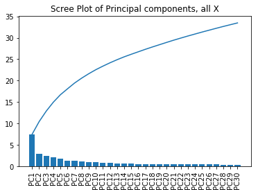

```python
%matplotlib inline
import matplotlib.pyplot as plt
from sklearn.decomposition import PCA
pca = PCA(n_components=30)
pca.fit(X)
X_pca = pca.transform(X)

pca_var= pca.explained_variance_ratio_
print('Variance Per PC: \n',pca_var)
plt.bar(['PC%s' %i for i in range(1,31)],pca_var*100)

pca_var_cumsum = np.cumsum(np.round(pca_var, decimals=4)*100)
print('Cumulative Variance: \n',pca_var_cumsum)

plt.plot(pca_var_cumsum)
plt.title('Scree Plot of Principal components, all X')
plt.xticks(rotation='vertical')
plt.show()
```

```python
import plotly.offline as py
py.init_notebook_mode(connected=True)
import plotly.graph_objs as go

trace = go.Scatter(x=X_pca[:, 0], y=X_pca[:, 1],
                     mode='markers',
                     marker=dict(color=y,
                                 line=dict(color='black', width=.5))
                     )

layout = go.Layout(scene=
                   dict(
                        xaxis=dict(ticks='', showticklabels=False),
                        yaxis=dict(ticks='', showticklabels=False)
                       ),
                   title = 'PCA of all X observations',
                   xaxis = dict(title = "PC1"),
                   yaxis = dict(title = "PC2"),
                  )

fig = go.Figure(data=[trace], layout=layout)

py.iplot(fig)
```

[interactive chart not shown]

PCA will give us an unbiased representation of the relationship of features per observation when projected onto a 2d plane. clusting of points shows likeness of features which can predict response. LDA uses the targets to find a suitable projection to maximize separation of features based on class.

From our model on the full dataset we have PC1 of which encompases ~7.5% of the data and a PC2 explaining ~3% of the data meaning the projection only explains ~10% of the data variance. The cumulative variance also does not converge to 100% at 30 components. Feature selection is definitely required before creating a predictive model.

```
Variance Per PC:
 [0.078215   0.02960096 0.02485165 0.02082893 0.0180168  0.01466576
 0.01379882 0.01234806 0.01142458 0.01018102 0.00907669 0.00852876
 0.00780165 0.00776414 0.00687399 0.00669733 0.00635271 0.00627843
 0.00604028 0.00590395 0.00567937 0.00565337 0.00556565 0.00550241
 0.00531113 0.00509264 0.00505571 0.00494564 0.00475673 0.00471063]
Cumulative Variance:
 [ 7.82 10.78 13.27 15.35 17.15 18.62 20.   21.23 22.37 23.39 24.3  25.15
 25.93 26.71 27.4  28.07 28.71 29.34 29.94 30.53 31.1  31.67 32.23 32.78
 33.31 33.82 34.33 34.82 35.3  35.77]
```

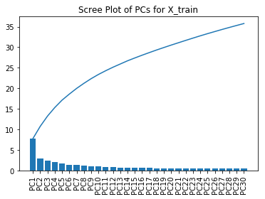

[interactive chart not shown]

```python
#PCA on x_train
def PCA_quickstat(X, n_components, screetitle = 'Scree Plot', pcatitle = 'PCA'):
    pca = PCA(n_components=n_components)
    pca.fit(X)
    X_pca = pca.transform(X)
    pca_var= pca.explained_variance_ratio_
    print('Variance Per PC: \n',pca_var)
    plt.bar(['PC%s' %i for i in range(1,n_components+1)],pca_var*100)

    pca_var_cumsum = np.cumsum(np.round(pca_var, decimals=4)*100)
    print('Cumulative Variance: \n',pca_var_cumsum)

    #Finish plotting scree
    plt.plot(pca_var_cumsum)
    plt.title(screetitle)
    plt.xticks(rotation='vertical')
    plt.show()

    #PCA1-2 on X_train
    trace = go.Scatter(x=X_pca[:, 0], y=X_pca[:, 1],
                         mode='markers',
                         marker=dict(color=y,
                                     line=dict(color='black', width=.5))
                         )

    layout = go.Layout(scene=
                       dict(
                            xaxis=dict(ticks='', showticklabels=False),
                            yaxis=dict(ticks='', showticklabels=False)
                           ),
                       title = pcatitle,
                       xaxis = dict(title = "PC1"),
                       yaxis = dict(title = "PC2"),
                      )

    fig = go.Figure(data=[trace], layout=layout)

    py.iplot(fig)

PCA_quickstat(X_train, 30, screetitle='Scree Plot of PCs for X_train', pcatitle='PCA of X_train Obs')
```

PCA of X_train for comparison after feature selection

```
Dims of X_train after Variance Threshold selection (371, 2043)
Variance Per PC:
 [0.10139037 0.0371113  0.03088208 0.02373509 0.0223868  0.01794904
 0.01554793 0.01469852 0.0131282  0.01159489 0.01016563 0.00939135
 0.00852069 0.00789751 0.00763134 0.00738185 0.0071971  0.0066801
 0.00654617 0.00628047 0.00621843 0.00592794 0.00573304 0.00548459
 0.00547964 0.00538585 0.0051926  0.00510786 0.00496874 0.00489869]
Cumulative Variance:
 [10.14 13.85 16.94 19.31 21.55 23.34 24.89 26.36 27.67 28.83 29.85 30.79
 31.64 32.43 33.19 33.93 34.65 35.32 35.97 36.6  37.22 37.81 38.38 38.93
 39.48 40.02 40.54 41.05 41.55 42.04]
```

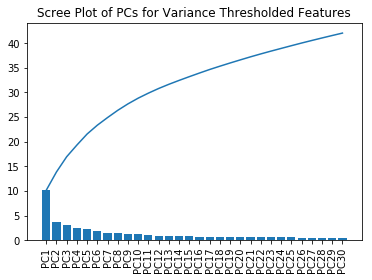

[interactive chart not shown]

```python
from sklearn.feature_selection import VarianceThreshold
fs_VarT = VarianceThreshold(threshold=0.1)
fs_VarT.fit(X_train)
X_train_VarT = fs_VarT.transform(X_train)
print('Dims of X_train after Variance Threshold selection',X_train_Vart.shape)
#Store for testing after model fits
X_test_VarT = fs_VarT.transform(X_test)
PCA_quickstat(X_train_Vart, 30, screetitle='Scree Plot of PCs for Variance Thresholded Features', pcatitle='PCA of X_train of obs for Variance Thresholded Features')
```

```
[False False False ... False False  True]
Selected columns:
 Index(['V13', 'V17', 'V30', 'V34', 'V40', 'V53', 'V60', 'V75', 'V76', 'V83',
       ...
       'V16484', 'V16485', 'V16502', 'V16542', 'V16543', 'V16545', 'V16547',
       'V16549', 'V16553', 'V16562'],
      dtype='object', length=2043)
```

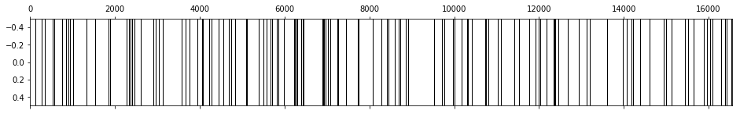

```python
mask = fs_VarT.get_support()
print(mask)
print('Selected columns: \n',X_train.columns[mask])
plt.matshow(mask.reshape(1,-1),cmap='gray_r',aspect='auto')
plt.show()
```

Throwing out low variance features will help remove low signal features which can add noise to a model. From the view of selected features there doesn't seem to be a large cluster of realated features however there are smaller groupings related features. Perhaps these relate to groups of relevant variables. If the features were identified we could examine them for classification. Perhaps using a supervised model will help extract relevant data.

```python
from sklearn.feature_selection import SelectKBest, chi2, f_classif
fs_KB_chi2_100 = SelectKBest(score_func=chi2,k=100)
fs_KB_chi2_1000 = SelectKBest(score_func=chi2,k=1000)
fs_KB_fcif_100 = SelectKBest(score_func=f_classif,k=100)
fs_KB_fcif_1000 = SelectKBest(score_func=f_classif,k=1000)

fs_KB_chi2_100.fit(X_train,y_train)
fs_KB_chi2_1000.fit(X_train,y_train)
fs_KB_fcif_100.fit(X_train,y_train)
fs_KB_fcif_1000.fit(X_train,y_train)

X_train_KB_chi2_100 = fs_KB_chi2_100.transform(X_train)
X_train_KB_chi2_1000 = fs_KB_chi2_1000.transform(X_train)
X_train_KB_fcif_100 = fs_KB_fcif_100.transform(X_train)
X_train_KB_fcif_1000 = fs_KB_fcif_1000.transform(X_train)

X_test_KB_chi2_100 = fs_KB_chi2_100.transform(X_test)
X_test_KB_chi2_1000 = fs_KB_chi2_1000.transform(X_test)
X_test_KB_fcif_100 = fs_KB_fcif_100.transform(X_test)
X_test_KB_fcif_1000 = fs_KB_fcif_1000.transform(X_test)
```

```
Selected columns:
 Index(['V27', 'V148', 'V867', 'V1289', 'V1525', 'V1528', 'V1606', 'V1700',
       'V1931', 'V1934', 'V2052', 'V2054', 'V2670', 'V3041', 'V3097', 'V3636',
       'V3643', 'V3685', 'V3717', 'V3948', 'V4131', 'V4421', 'V4504', 'V4686',
       'V5592', 'V5631', 'V5697', 'V5859', 'V5930', 'V6013', 'V6062', 'V6238',
       'V6344', 'V6371', 'V6513', 'V6520', 'V6544', 'V6559', 'V6883', 'V6992',
       'V7151', 'V7190', 'V7454', 'V7515', 'V7663', 'V7680', 'V7990', 'V8401',
       'V8418', 'V8446', 'V8511', 'V8533', 'V8768', 'V9211', 'V9423', 'V9510',
       'V9627', 'V9710', 'V9867', 'V9963', 'V10273', 'V10480', 'V10488',
       'V10770', 'V11162', 'V11437', 'V11634', 'V11902', 'V12338', 'V12484',
       'V12595', 'V12819', 'V12938', 'V12949', 'V13059', 'V13172', 'V13259',
       'V13435', 'V13603', 'V13694', 'V13894', 'V13916', 'V14413', 'V14445',
       'V14513', 'V14908', 'V15133', 'V15158', 'V15176', 'V15182', 'V15261',
       'V15368', 'V15650', 'V15819', 'V15944', 'V16099', 'V16149', 'V16390',
       'V16444', 'V16509'],
      dtype='object')
Number of features selected:  100
```

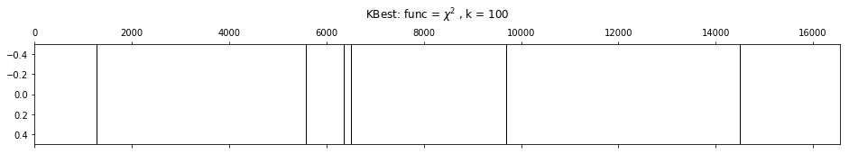

```
Selected columns:
 Index(['V27', 'V46', 'V71', 'V114', 'V125', 'V131', 'V147', 'V148', 'V164',
       'V202',
       ...
       'V16427', 'V16442', 'V16444', 'V16474', 'V16480', 'V16482', 'V16497',
       'V16509', 'V16517', 'V16553'],
      dtype='object', length=1000)
Number of features selected:  1000
```

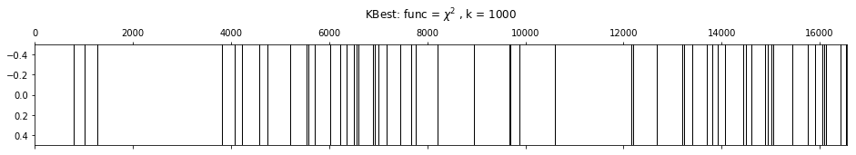

```
Selected columns:
 Index(['V27', 'V148', 'V655', 'V867', 'V1181', 'V1528', 'V1606', 'V1700',
       'V1931', 'V1934', 'V2022', 'V2052', 'V2054', 'V2148', 'V2670', 'V3097',
       'V3636', 'V3643', 'V3685', 'V3717', 'V3948', 'V4131', 'V4421', 'V4504',
       'V4686', 'V5592', 'V5631', 'V5697', 'V5722', 'V5859', 'V5930', 'V6013',
       'V6062', 'V6238', 'V6371', 'V6513', 'V6544', 'V6559', 'V6883', 'V6992',
       'V7151', 'V7190', 'V7370', 'V7451', 'V7454', 'V7515', 'V7663', 'V7680',
       'V7990', 'V8401', 'V8446', 'V8511', 'V8533', 'V8664', 'V8768', 'V9211',
       'V9307', 'V9423', 'V9627', 'V9867', 'V9963', 'V10273', 'V10426',
       'V10480', 'V10770', 'V11181', 'V11328', 'V12338', 'V12484', 'V12589',
       'V12595', 'V12819', 'V12938', 'V12949', 'V13059', 'V13118', 'V13172',
       'V13259', 'V13435', 'V13578', 'V13603', 'V13894', 'V14413', 'V14445',
       'V14513', 'V14624', 'V14883', 'V14908', 'V15133', 'V15182', 'V15261',
       'V15295', 'V15368', 'V15944', 'V16099', 'V16149', 'V16258', 'V16390',
       'V16444', 'V16509'],
      dtype='object')
Number of features selected:  100
```

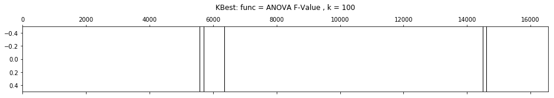

```
Selected columns:
 Index(['V27', 'V46', 'V71', 'V114', 'V131', 'V140', 'V147', 'V148', 'V164',
       'V202',
       ...
       'V16385', 'V16390', 'V16401', 'V16442', 'V16444', 'V16482', 'V16502',
       'V16509', 'V16517', 'V16553'],
      dtype='object', length=1000)
Number of features selected:  1000
```

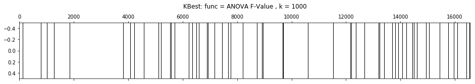

```python
def fs_plot(fs_fit, X, title = 'Features'):
    mask = fs_fit.get_support()
    print('Selected columns: \n',X.columns[mask])
    print('Number of features selected: ', X.columns[mask].shape[0])
    plt.matshow(mask.reshape(1,-1),cmap='gray_r',aspect='auto')
    plt.title(title, y = 1.2)
    plt.show()

fs_plot(fs_KB_chi2_100, X_train, title = 'KBest: func = $\chi ^2$ , k = 100')
fs_plot(fs_KB_chi2_1000, X_train, title = 'KBest: func = $\chi ^2$ , k = 1000')
fs_plot(fs_KB_fcif_100, X_train, title = 'KBest: func = ANOVA F-Value , k = 100')
fs_plot(fs_KB_fcif_1000, X_train, title = 'KBest: func = ANOVA F-Value , k = 1000')
```

Ideally a pipeline testing the performance of each feature selection method and parameter in conjunction with the built model would work best however for simplicity sake the exploration will try a few feature selection methods on a few models.

Will use k=1000 and function chi^2 and ANOVA . Problem with kbest is dependance on the k value which will either leave in features which cause noise or remove important features for classification.

Will skip recursive feature elimination due to poor speed and that we can achieve a better selection through the use of LASSO regression and random forest classifiers.

```
Variance Per PC:
 [0.08526062 0.05114459 0.02703844 0.02218178 0.01917941 0.01643599
 0.01564189 0.01381267 0.01344147 0.01224589 0.01103676 0.00990775
 0.00963241 0.00952467 0.00920799 0.00860805 0.00841924 0.0082586
 0.00774079 0.00750721 0.00747968 0.00729984 0.00696545 0.0068096
 0.00651451 0.00643001 0.00631445 0.00623956 0.00610718 0.00603401]
Cumulative Variance:
 [ 8.53 13.64 16.34 18.56 20.48 22.12 23.68 25.06 26.4  27.62 28.72 29.71
 30.67 31.62 32.54 33.4  34.24 35.07 35.84 36.59 37.34 38.07 38.77 39.45
 40.1  40.74 41.37 41.99 42.6  43.2 ]
```

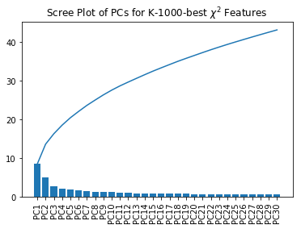

[interactive chart not shown]

```python
PCA_quickstat(X_train_KB_chi2_1000, 30, screetitle='Scree Plot of PCs for K-1000-best $\chi^2$ Features', pcatitle='PCA of X_train of obs for K-1000-best chi-squared univariate selected Features')
```

```
Variance Per PC:
 [0.18441608 0.05973953 0.04940475 0.03819366 0.03265816 0.03012524
 0.02709077 0.02545864 0.02499336 0.02380202 0.0224016  0.02081854
 0.0206675  0.01900843 0.01790046 0.0166216  0.01625889 0.01577519
 0.01556286 0.01519208 0.01420954 0.01358243 0.01310441 0.0129456
 0.01195157 0.01177364 0.010826   0.01075875 0.00979398 0.00967266]
Cumulative Variance:
 [18.44 24.41 29.35 33.17 36.44 39.45 42.16 44.71 47.21 49.59 51.83 53.91
 55.98 57.88 59.67 61.33 62.96 64.54 66.1  67.62 69.04 70.4  71.71 73.
 74.2  75.38 76.46 77.54 78.52 79.49]
```

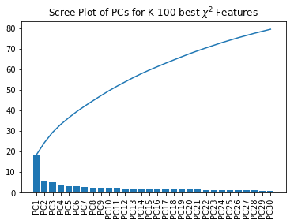

[interactive chart not shown]

```python
PCA_quickstat(X_train_KB_chi2_100, 30, screetitle='Scree Plot of PCs for K-100-best $\chi^2$ Features', pcatitle='PCA of X_train of obs for K-100-best chi-squared univariate selected Features')
```

```python
from sklearn.linear_model import LassoCV
from sklearn.feature_selection import SelectFromModel

fs_LASSO = SelectFromModel(LassoCV(cv=5, n_jobs=-1))
fs_LASSO.fit(X_train,y_train)
X_train_LASSO = fs_LASSO.transform(X_train)
#Store for later
X_test_LASSO = fs_LASSO.transform(X_test)
```

```
Selected columns:
 Index(['V1144', 'V1931', 'V2148', 'V2313', 'V2670', 'V3040', 'V3305', 'V3685',
       'V3882', 'V4185', 'V4297', 'V4445', 'V4762', 'V4863', 'V5930', 'V6289',
       'V6755', 'V6909', 'V7451', 'V7972', 'V8209', 'V8768', 'V8975', 'V9090',
       'V9111', 'V9740', 'V9867', 'V10180', 'V10450', 'V10519', 'V10769',
       'V10842', 'V11333', 'V11579', 'V11707', 'V11746', 'V11956', 'V12047',
       'V12819', 'V13172', 'V13578', 'V14087', 'V14353', 'V14694', 'V14729',
       'V15261', 'V15303', 'V16258'],
      dtype='object')
Number of features selected:  48
```

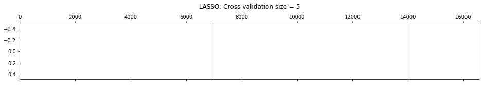

```python
fs_plot(fs_LASSO, X_train, title = 'LASSO: Cross validation size = 5')
```

```python
from sklearn.ensemble import RandomForestClassifier
fs_RFC = SelectFromModel(RandomForestClassifier(n_estimators=100))
fs_RFC.fit(X_train, y_train)
X_train_RFC = fs_RFC.transform(X_train)
#Store for later
X_test_RFC = fs_RFC.transform(X_test)
```

```
Selected columns:
 Index(['V2', 'V8', 'V13', 'V17', 'V25', 'V27', 'V34', 'V40', 'V42', 'V52',
       ...
       'V16517', 'V16520', 'V16523', 'V16532', 'V16542', 'V16543', 'V16545',
       'V16549', 'V16553', 'V16562'],
      dtype='object', length=2864)
Number of features selected:  2864
```

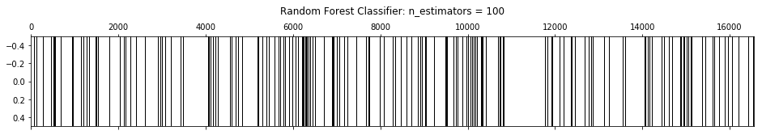

```python
fs_plot(fs_RFC, X_train, title = 'Random Forest Classifier: n_estimators = 100')
```

### Modeling Data Using Selected Features

```python
from sklearn.neighbors import KNeighborsClassifier
from sklearn.model_selection import cross_val_score
k_range = range(1,31)
k_scores = []
for k in k_range:
    clf_KNN = KNeighborsClassifier(n_neighbors=k)
    scores = cross_val_score(clf_KNN, X_train, y_train, cv=10, scoring='accuracy')
    k_scores.append(scores.mean())
print(k_scores)
```

```
[0.7123123123123123, 0.7576971708550655, 0.7360715979137031, 0.7576220957799904, 0.7572585743638375, 0.7626639797692429, 0.7628813023549865, 0.7628101785996523, 0.76558795637743, 0.7683657341552078, 0.7629603287498024, 0.7601825509720246, 0.7601825509720246, 0.7574047731942468, 0.7601825509720246, 0…
```

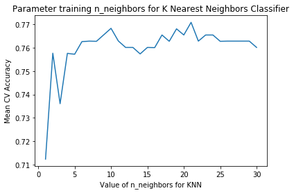

```python
plt.plot(k_range, k_scores)
plt.xlabel("Value of n_neighbors for KNN")
plt.ylabel("Mean CV Accuracy")
k_scores.index(max(k_scores))
plt.title('Parameter training n_neighbors for K Nearest Neighbors Classifier')
plt.show()
```

Iterating on k using cross validation teases out an optimal k near the end of our range of selected k which is optimal for KNN as higher K lowers model complexity. K-NN is unfortunately vulnurable to noisy data and as such estimations on X_test will probably not be very accurate.

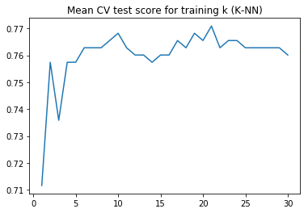

```
Accuracy Score between y predicted and y_train:  0.7816711590296496
Best Params:  {'n_neighbors': 21}
Accuracy Score between y predicted and y_test 0.7924528301886793
```

```python
#Use GridSearchCV to find parameters easier
from sklearn.model_selection import GridSearchCV
from sklearn import metrics
#wt_opts = ['uniform', 'distance']
#param_grid = dict(n_neighbors=k_range,weights=wt_opts)
k_range = range(1,31)
param_grid = dict(n_neighbors=k_range)
clf_KNN = KNeighborsClassifier()
grid = GridSearchCV(clf_KNN, param_grid, cv=10, scoring='accuracy',n_jobs=-1)
grid.fit(X_train, y_train)
plt.plot(k_range,grid.cv_results_['mean_test_score'])
plt.title('Mean CV test score for training k (K-NN)')
plt.show()

print('Accuracy Score between y predicted and y_train: ',metrics.accuracy_score(y_train,grid.predict(X_train)))
print('Best Params: ',grid.best_params_)
y_pred = grid.predict(X_test)
print('Accuracy Score between y predicted and y_test',metrics.accuracy_score(y_test,y_pred))
```

```python
print(y_test.value_counts(normalize=True)) #Null accuracy shows that predicting only most frequent class is close to the same probabilty
#Therefore model outcome is not great
print(metrics.confusion_matrix(y_test, y_pred))#Confusion matrix shows that we have classifying as 0 when the model should be predicted as 1!
#High false negative
#Tuning threshold to allow more positive responses to occur may be beneficial but without knowing reason for data not advisable
y_pred_probs = grid.predict_proba(X_test)[:,1]
```

```
0    0.779874
1    0.220126
Name: response, dtype: float64
[[124   0]
 [ 33   2]]
```

The confusion matrix shows that a large amount of what should have been identified as positive (1) was identified as negative (0) meaning there is a high false negative rate amongst this predictor. The frequency of negative in our data is ~0.78 meaning if the model were to only predict negative it would be 78% accurate. The predictive score of K-NN without any feature filtering is 79% meaning its just about the same as just predicting every response to be negative.

```
The AUC is: 0.6649
```

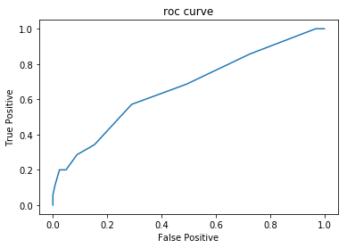

```python
fpr, tpr, thresholds = metrics.roc_curve(y_test,y_pred_probs)
plt.plot(fpr,tpr)
plt.title('roc curve')
plt.xlabel('False Positive')
plt.ylabel('True Positive')
print('The AUC is: {:.4f}'.format(metrics.roc_auc_score(y_test, y_pred_probs)))
```

The closer a ROC curve is to the top left, the better the model is. The curve presents a glimps at how tuning the threshold for what is decided as positive will affect the prediction.

```python
def grid_clf_test(clf, param_grid, X_train,y_train,X_test,y_test,cv=10,scoring='accuracy'):
    grid = GridSearchCV(clf,param_grid=param_grid, cv=cv, scoring=scoring, n_jobs=-1)
    grid.fit(X_train,y_train)
    print('The best params: ', grid.best_params_)
    grid.predict(X_train)
    print('Prediction accuracy to training class: ',metrics.accuracy_score(y_train,grid.predict(X_train)))
    y_pred = grid.predict(X_test)
    print('Prediction accuracy to test class: ',metrics.accuracy_score(y_test,y_pred))
    print('Value Counts for Null prediction: \n',y_test.value_counts(normalize=True))
    print(metrics.confusion_matrix(y_test, y_pred))
    print(metrics.classification_report(y_test,y_pred))
    y_pred_probs = grid.predict_proba(X_test)[:,1]
    fpr, tpr, thresholds = metrics.roc_curve(y_test,y_pred_probs)
    plt.plot(fpr,tpr)
    plt.title('roc curve')
    plt.xlabel('False Positive')
    plt.ylabel('True Positive')
    print('The AUC is: {:.4f}'.format(metrics.roc_auc_score(y_test, y_pred_probs)))
```

```
The best params:  {'n_neighbors': 5}
Prediction accuracy to training class:  0.8598382749326146
Prediction accuracy to test class:  0.8238993710691824
Value Counts for Null prediction:
 0    0.779874
1    0.220126
Name: response, dtype: float64
[[121   3]
 [ 25  10]]
              precision    recall  f1-score   support

           0       0.83      0.98      0.90       124
           1       0.77      0.29      0.42        35

   micro avg       0.82      0.82      0.82       159
   macro avg       0.80      0.63      0.66       159
weighted avg       0.82      0.82      0.79       159

The AUC is: 0.7225
```

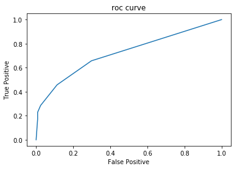

```python
#Try K-NN again with more sparse feature sets
#Kbest using chi2 selection of 100 best
k_range = range(1,31)
param_grid = dict(n_neighbors=k_range)
clf_KNN = KNeighborsClassifier()
grid_clf_test(clf_KNN,param_grid,X_train_KB_chi2_100,y_train,X_test_KB_chi2_100,y_test)
```

```
The best params:  {'n_neighbors': 7}
Prediction accuracy to training class:  0.8194070080862533
Prediction accuracy to test class:  0.7924528301886793
Value Counts for Null prediction:
 0    0.779874
1    0.220126
Name: response, dtype: float64
[[123   1]
 [ 32   3]]
              precision    recall  f1-score   support

           0       0.79      0.99      0.88       124
           1       0.75      0.09      0.15        35

   micro avg       0.79      0.79      0.79       159
   macro avg       0.77      0.54      0.52       159
weighted avg       0.78      0.79      0.72       159

The AUC is: 0.6632
```

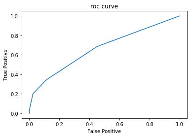

```python
#Kbest using chi2 selection of 1000 best to compare
grid_clf_test(clf_KNN,param_grid,X_train_KB_chi2_1000,y_train,X_test_KB_chi2_1000,y_test)
```

```
The best params:  {'n_neighbors': 5}
Prediction accuracy to training class:  0.8814016172506739
Prediction accuracy to test class:  0.8238993710691824
Value Counts for Null prediction:
 0    0.779874
1    0.220126
Name: response, dtype: float64
[[122   2]
 [ 26   9]]
              precision    recall  f1-score   support

           0       0.82      0.98      0.90       124
           1       0.82      0.26      0.39        35

   micro avg       0.82      0.82      0.82       159
   macro avg       0.82      0.62      0.64       159
weighted avg       0.82      0.82      0.79       159

The AUC is: 0.7749
```

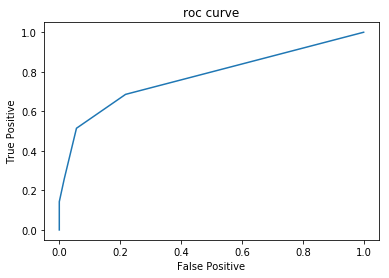

```python
#KNN again with aggressive feature reduction from LASSO
grid_clf_test(clf_KNN,param_grid,X_train_LASSO,y_train,X_test_LASSO,y_test)
```

```
The best params:  {'n_neighbors': 3}
Prediction accuracy to training class:  0.8355795148247979
Prediction accuracy to test class:  0.8050314465408805
Value Counts for Null prediction:
 0    0.779874
1    0.220126
Name: response, dtype: float64
[[124   0]
 [ 31   4]]
              precision    recall  f1-score   support

           0       0.80      1.00      0.89       124
           1       1.00      0.11      0.21        35

   micro avg       0.81      0.81      0.81       159
   macro avg       0.90      0.56      0.55       159
weighted avg       0.84      0.81      0.74       159

The AUC is: 0.6143
```

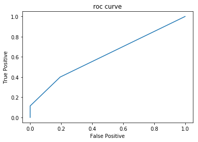

```python
#KNN with RFC set. Compare large RFC set with small LASSO
grid_clf_test(clf_KNN,param_grid,X_train_RFC,y_train,X_test_RFC,y_test)
```

Using K-NN helps show the effect of each feature reduction method. As a model it performs very poorly with several models being very close to NULL prediction (accuracy of choosing only 0 or only 1 depending on max frequency). We could see from the PCAs that likeness of data is not close enough for an algorithm like K-NN to work well.

```
The best params:  {}
Prediction accuracy to training class:  1.0
Prediction accuracy to test class:  0.8930817610062893
Value Counts for Null prediction:
 0    0.779874
1    0.220126
Name: response, dtype: float64
[[122   2]
 [ 15  20]]
              precision    recall  f1-score   support

           0       0.89      0.98      0.93       124
           1       0.91      0.57      0.70        35

   micro avg       0.89      0.89      0.89       159
   macro avg       0.90      0.78      0.82       159
weighted avg       0.89      0.89      0.88       159

The AUC is: 0.8768
```

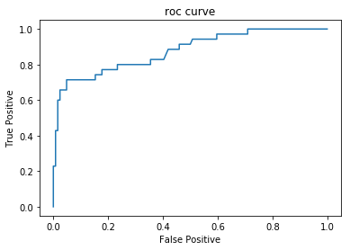

```python
#LogReg on unfiltered test data
from sklearn.linear_model import LogisticRegression
clf_RFC = RandomForestClassifier(n_estimators=1000)
param_grid={}
#Give RFC increase in estimator should only help. Let model auto tune max-features
grid_clf_test(clf_RFC,{},X_train,y_train,X_test,y_test)
```

```
The best params:  {}
Prediction accuracy to training class:  1.0
Prediction accuracy to test class:  0.8427672955974843
Value Counts for Null prediction:
 0    0.779874
1    0.220126
Name: response, dtype: float64
[[123   1]
 [ 24  11]]
              precision    recall  f1-score   support

           0       0.84      0.99      0.91       124
           1       0.92      0.31      0.47        35

   micro avg       0.84      0.84      0.84       159
   macro avg       0.88      0.65      0.69       159
weighted avg       0.85      0.84      0.81       159

The AUC is: 0.8758
```

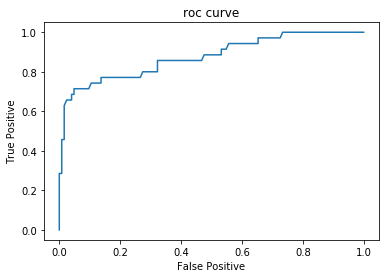

```python
#LogReg on Vart test data
from sklearn.linear_model import LogisticRegression
clf_RFC = RandomForestClassifier(n_estimators=1000)
param_grid={}
#Give RFC increase in estimator should only help. Let model auto tune max-features
grid_clf_test(clf_RFC,{},X_train_VarT,y_train,X_test_VarT,y_test)
```

```
The best params:  {}
Prediction accuracy to training class:  0.9919137466307277
Prediction accuracy to test class:  0.9056603773584906
Value Counts for Null prediction:
 0    0.779874
1    0.220126
Name: response, dtype: float64
[[121   3]
 [ 12  23]]
              precision    recall  f1-score   support

           0       0.91      0.98      0.94       124
           1       0.88      0.66      0.75        35

   micro avg       0.91      0.91      0.91       159
   macro avg       0.90      0.82      0.85       159
weighted avg       0.90      0.91      0.90       159

The AUC is: 0.8516
```

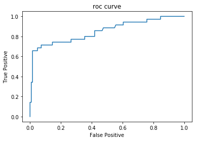

```python
#LogReg on KB chi2 100 test data
from sklearn.linear_model import LogisticRegression
clf_RFC = RandomForestClassifier(n_estimators=1000)
param_grid={}
#Give RFC increase in estimator should only help. Let model auto tune max-features
grid_clf_test(clf_RFC,{},X_train_KB_chi2_100,y_train,X_test_KB_chi2_100,y_test)
```

```
The best params:  {}
Prediction accuracy to training class:  1.0
Prediction accuracy to test class:  0.9119496855345912
Value Counts for Null prediction:
 0    0.779874
1    0.220126
Name: response, dtype: float64
[[122   2]
 [ 12  23]]
              precision    recall  f1-score   support

           0       0.91      0.98      0.95       124
           1       0.92      0.66      0.77        35

   micro avg       0.91      0.91      0.91       159
   macro avg       0.92      0.82      0.86       159
weighted avg       0.91      0.91      0.91       159

The AUC is: 0.8748
```

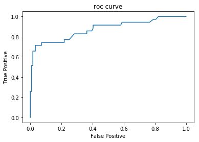

```python
#LogReg on KB chi2 1000 test data
from sklearn.linear_model import LogisticRegression
clf_RFC = RandomForestClassifier(n_estimators=1000)
param_grid={}
#Give RFC increase in estimator should only help. Let model auto tune max-features
grid_clf_test(clf_RFC,{},X_train_KB_chi2_1000,y_train,X_test_KB_chi2_1000,y_test)
```

```
The best params:  {}
Prediction accuracy to training class:  1.0
Prediction accuracy to test class:  0.9119496855345912
Value Counts for Null prediction:
 0    0.779874
1    0.220126
Name: response, dtype: float64
[[122   2]
 [ 12  23]]
              precision    recall  f1-score   support

           0       0.91      0.98      0.95       124
           1       0.92      0.66      0.77        35

   micro avg       0.91      0.91      0.91       159
   macro avg       0.92      0.82      0.86       159
weighted avg       0.91      0.91      0.91       159

The AUC is: 0.8782
```

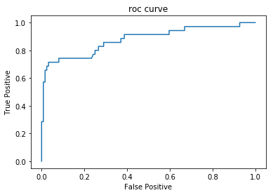

```python
#LogReg on KB fcif 1000 test data
from sklearn.linear_model import LogisticRegression
clf_RFC = RandomForestClassifier(n_estimators=1000)
param_grid={}
#Give RFC increase in estimator should only help. Let model auto tune max-features
grid_clf_test(clf_RFC,{},X_train_KB_fcif_1000,y_train,X_test_KB_fcif_1000,y_test)
```

```
The best params:  {}
Prediction accuracy to training class:  1.0
Prediction accuracy to test class:  0.9119496855345912
Value Counts for Null prediction:
 0    0.779874
1    0.220126
Name: response, dtype: float64
[[121   3]
 [ 11  24]]
              precision    recall  f1-score   support

           0       0.92      0.98      0.95       124
           1       0.89      0.69      0.77        35

   micro avg       0.91      0.91      0.91       159
   macro avg       0.90      0.83      0.86       159
weighted avg       0.91      0.91      0.91       159

The AUC is: 0.8788
```

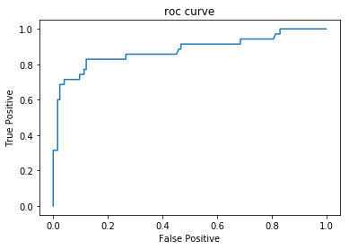

```python
#LogReg on LASSO test data
from sklearn.linear_model import LogisticRegression
clf_RFC = RandomForestClassifier(n_estimators=1000)
param_grid={}
#Give RFC increase in estimator should only help. Let model auto tune max-features
grid_clf_test(clf_RFC,{},X_train_LASSO,y_train,X_test_LASSO,y_test)
```

```
The best params:  {}
Prediction accuracy to training class:  1.0
Prediction accuracy to test class:  0.89937106918239
Value Counts for Null prediction:
 0    0.779874
1    0.220126
Name: response, dtype: float64
[[122   2]
 [ 14  21]]
              precision    recall  f1-score   support

           0       0.90      0.98      0.94       124
           1       0.91      0.60      0.72        35

   micro avg       0.90      0.90      0.90       159
   macro avg       0.91      0.79      0.83       159
weighted avg       0.90      0.90      0.89       159

The AUC is: 0.8749
```

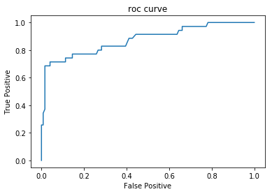

```python
#LogReg on RFC test data
from sklearn.linear_model import LogisticRegression
clf_RFC = RandomForestClassifier(n_estimators=1000)
param_grid={}
#Give RFC increase in estimator should only help. Let model auto tune max-features
grid_clf_test(clf_RFC,{},X_train_RFC,y_train,X_test_RFC,y_test)
```

```
The best params:  {'C': 0.01, 'kernel': 'linear'}
Prediction accuracy to training class:  1.0
Prediction accuracy to test class:  0.8742138364779874
Value Counts for Null prediction:
 0    0.779874
1    0.220126
Name: response, dtype: float64
[[120   4]
 [ 16  19]]
              precision    recall  f1-score   support

           0       0.88      0.97      0.92       124
           1       0.83      0.54      0.66        35

   micro avg       0.87      0.87      0.87       159
   macro avg       0.85      0.76      0.79       159
weighted avg       0.87      0.87      0.86       159

The AUC is: 0.9101
```

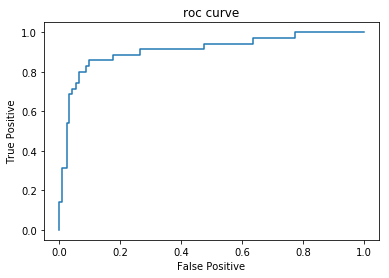

```python
#SVC on full X train
from sklearn.svm import SVC
param_grid={'kernel': ['linear', 'rbf', 'poly'],
            'C': [0.001,0.01, 0.1, 1, 10, 100]}
clf_SVC = SVC(probability=True)
grid_clf_test(clf_SVC,param_grid,X_train,y_train,X_test,y_test)
```

```
The best params:  {'C': 10, 'kernel': 'rbf'}
Prediction accuracy to training class:  0.9649595687331537
Prediction accuracy to test class:  0.8930817610062893
Value Counts for Null prediction:
 0    0.779874
1    0.220126
Name: response, dtype: float64
[[120   4]
 [ 13  22]]
              precision    recall  f1-score   support

           0       0.90      0.97      0.93       124
           1       0.85      0.63      0.72        35

   micro avg       0.89      0.89      0.89       159
   macro avg       0.87      0.80      0.83       159
weighted avg       0.89      0.89      0.89       159

The AUC is: 0.8793
```

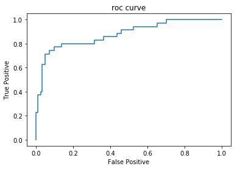

```python
#SVC with K-1000-best Chi2
from sklearn.svm import SVC
param_grid={'kernel': ['linear', 'rbf', 'poly'],
            'C': [0.001,0.01, 0.1, 1, 10, 100]}
clf_SVC = SVC(probability=True)
grid_clf_test(clf_SVC,param_grid,X_train_KB_chi2_1000,y_train,X_test_KB_chi2_1000,y_test)
```

```
The best params:  {'C': 10, 'kernel': 'rbf'}
Prediction accuracy to training class:  0.9811320754716981
Prediction accuracy to test class:  0.8616352201257862
Value Counts for Null prediction:
 0    0.779874
1    0.220126
Name: response, dtype: float64
[[115   9]
 [ 13  22]]
              precision    recall  f1-score   support

           0       0.90      0.93      0.91       124
           1       0.71      0.63      0.67        35

   micro avg       0.86      0.86      0.86       159
   macro avg       0.80      0.78      0.79       159
weighted avg       0.86      0.86      0.86       159

The AUC is: 0.8505
```

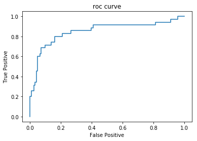

```python
#SVC with LASSO reduced set
from sklearn.svm import SVC
param_grid={'kernel': ['linear', 'rbf', 'poly'],
            'C': [0.001,0.01, 0.1, 1, 10, 100]}
clf_SVC = SVC(probability=True)
grid_clf_test(clf_SVC,param_grid,X_train_LASSO,y_train,X_test_LASSO,y_test)
```

```
The best params:  {'C': 0.01, 'kernel': 'linear'}
Prediction accuracy to training class:  0.9946091644204852
Prediction accuracy to test class:  0.8742138364779874
Value Counts for Null prediction:
 0    0.779874
1    0.220126
Name: response, dtype: float64
[[120   4]
 [ 16  19]]
              precision    recall  f1-score   support

           0       0.88      0.97      0.92       124
           1       0.83      0.54      0.66        35

   micro avg       0.87      0.87      0.87       159
   macro avg       0.85      0.76      0.79       159
weighted avg       0.87      0.87      0.86       159

The AUC is: 0.8887
```

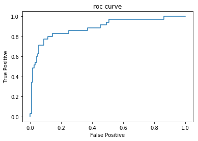

```python
#SVC with RFC reduced set
from sklearn.svm import SVC
param_grid={'kernel': ['linear', 'rbf', 'poly'],
            'C': [0.001,0.01, 0.1, 1, 10, 100]}
clf_SVC = SVC(probability=True)
grid_clf_test(clf_SVC,param_grid,X_train_RFC,y_train,X_test_RFC,y_test)
```

Support Vecto Machines are able to handle outliers fairly well and it shows as reducing the dataset with LASSO most likely removed some data required for SVM to optimize. 89% Accuracy with K Best univariate selection using $\chi^2$ turns out to be the best for this model.

```
The best params:  {'max_depth': 1, 'n_estimators': 50}
Prediction accuracy to training class:  0.8787061994609164
Prediction accuracy to test class:  0.89937106918239
Value Counts for Null prediction:
 0    0.779874
1    0.220126
Name: response, dtype: float64
[[120   4]
 [ 12  23]]
              precision    recall  f1-score   support

           0       0.91      0.97      0.94       124
           1       0.85      0.66      0.74        35

   micro avg       0.90      0.90      0.90       159
   macro avg       0.88      0.81      0.84       159
weighted avg       0.90      0.90      0.89       159

The AUC is: 0.8471
```

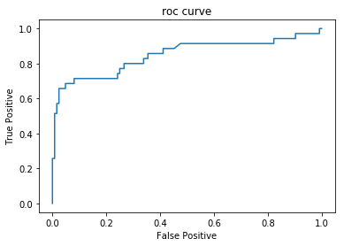

```python
from xgboost import XGBClassifier
clf_XGB = XGBClassifier()
n_estimators=range(50,400,50)
max_depth=range(1,11,2)
param_grid=dict(n_estimators=n_estimators, max_depth=max_depth)
grid_clf_test(clf_XGB,param_grid,X_train,y_train,X_test,y_test)
```

```
The best params:  {'max_depth': 3, 'n_estimators': 200}
Prediction accuracy to training class:  1.0
Prediction accuracy to test class:  0.8553459119496856
Value Counts for Null prediction:
 0    0.779874
1    0.220126
Name: response, dtype: float64
[[114  10]
 [ 13  22]]
              precision    recall  f1-score   support

           0       0.90      0.92      0.91       124
           1       0.69      0.63      0.66        35

   micro avg       0.86      0.86      0.86       159
   macro avg       0.79      0.77      0.78       159
weighted avg       0.85      0.86      0.85       159

The AUC is: 0.8546
```

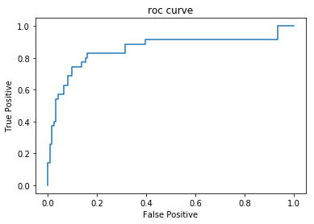

```python
#XGBoost is known to work similarly on minimally reduced sets however lets see if the LASSO reduced set will help training or speed
clf_XGB = XGBClassifier()
n_estimators=range(50,400,50)
max_depth=range(1,11,2)
param_grid=dict(n_estimators=n_estimators, max_depth=max_depth)
grid_clf_test(clf_XGB,param_grid,X_train_LASSO,y_train,X_test_LASSO,y_test)
```

XGBoost uses multiple decision trees to create a prediction and works well to perform feature selection on its own. Reducing the features with LASSO actually decreased performance overall. Like many of the models shown the accuracy seems to maximize around 89-91% at best.

Discussion:Overall

Multiple test/train splits could have been created in a loop and the models optimized for best mean performers as well as piping feature selection methods and models together and using GridSearchCV to find the optimal pipeline.